# 1-CONTEXT

The dataset provided is from the retail store called Cardio Good Fitness and contains the different attributes of the fitness members who is using the fitness product.The aim is to perform a detailed analysis of this dataset and provide useful insights to increase satisfaction and utilize the capacity of fitness center.

# 2-DATA DESCRIPTION:

Data Dictionary of Cardio Good Fitness

The data is about customers of the treadmill product(s) of a retail store called *Cardio Good Fitness*.

It contains the following variables-

- Product - The model no. of the treadmill
- Age - Age of the customer in no of years
- Gender - Gender of the customer
- Education - Education of the customer in no. of years
- Marital Status - Marital status of the customer
- Usage - Avg. # times the customer wants to use the treadmill every week
- Fitness - Self rated fitness score of the customer (5 - very fit, 1 - very unfit)
- Income - Income of the customer
- Miles- Miles that a customer expects to run

# 3-SANITY CHECKS

**Importing necessary libraries**

```python
# Libraries to help with reading and manipulating data
# NumPy is a python library mainly used for working with arrays and to perform a wide variety of mathematical operations on arrays
# Pandas is a Python library for data analysis
import pandas as pd
# Matplotlib is a comprehensive library for creating static, animated, and interactive visualizations in Python
import matplotlib.pyplot as plt
# Seaborn is a Python data visualization library based on matplotlib
import seaborn as sns
# to restrict the float value to 3 decimal places
pd.set_option('display.float_format', lambda x: '%.3f' % x)
import warnings
warnings.filterwarnings("ignore")
from PIL import Image
```

**Importing the dataset**

```python
# Getting the data from CSV file from Google Drive
data = pd.read_csv('/content/drive/MyDrive/GreatLearning/Project_CardioGoodFitness/CardioGoodFitness.csv')
```

**Checking the FIRST 5 rows of DATA**

```python
# Gets first 5 rows of DATA
data.head()
```

|  | Product | Age | Gender | Education | MaritalStatus | Usage | Fitness | Income | Miles |
| --- | --- | --- | --- | --- | --- | --- | --- | --- | --- |
| 0 | TM195 | 18 | Male | 14 | Single | 3 | 4 | 29562 | 112 |
| 1 | TM195 | 19 | Male | 15 | Single | 2 | 3 | 31836 | 75 |
| 2 | TM195 | 19 | Female | 14 | Partnered | 4 | 3 | 30699 | 66 |
| 3 | TM195 | 19 | Male | 12 | Single | 3 | 3 | 32973 | 85 |
| 4 | TM195 | 20 | Male | 13 | Partnered | 4 | 2 | 35247 | 47 |

**Checking the LAST 5 rows of DATA**

```python
# Gets last 5 rows of DATA
data.tail()
```

|  | Product | Age | Gender | Education | MaritalStatus | Usage | Fitness | Income | Miles |
| --- | --- | --- | --- | --- | --- | --- | --- | --- | --- |
| 175 | TM798 | 40 | Male | 21 | Single | 6 | 5 | 83416 | 200 |
| 176 | TM798 | 42 | Male | 18 | Single | 5 | 4 | 89641 | 200 |
| 177 | TM798 | 45 | Male | 16 | Single | 5 | 5 | 90886 | 160 |
| 178 | TM798 | 47 | Male | 18 | Partnered | 4 | 5 | 104581 | 120 |
| 179 | TM798 | 48 | Male | 18 | Partnered | 4 | 5 | 95508 | 180 |

**Checking the shape of DATA**

```python
# To know how many ROWS and COLUMNS exits at the data
print("CARDIO GOOD FITNESS DATA CONTAINS", data.shape[0], 'ROWS AND', data.shape[1], "COLUMNS")
```

```
CARDIO GOOD FITNESS DATA CONTAINS 180 ROWS AND 9 COLUMNS
```

**Check the data types of the columns for the dataset**

```python
#Check data type
data.info()
```

```
<class 'pandas.core.frame.DataFrame'>
RangeIndex: 180 entries, 0 to 179
Data columns (total 9 columns):
 #   Column         Non-Null Count  Dtype
---  ------         --------------  -----
 0   Product        180 non-null    object
 1   Age            180 non-null    int64
 2   Gender         180 non-null    object
 3   Education      180 non-null    int64
 4   MaritalStatus  180 non-null    object
 5   Usage          180 non-null    int64
 6   Fitness        180 non-null    int64
 7   Income         180 non-null    int64
 8   Miles          180 non-null    int64
dtypes: int64(6), object(3)
memory usage: 12.8+ KB
```

- There are 6 numerical columns in the data and 3 object type columns.

```python
#Checks the missing value at Data
data.isnull().sum()
```

```
Product          0
Age              0
Gender           0
Education        0
MaritalStatus    0
Usage            0
Fitness          0
Income           0
Miles            0
dtype: int64
```

Checking the missing values at data , no missing value

```python
# Function checks the unique product types
data['Product'].unique()
```

```
array(['TM195', 'TM498', 'TM798'], dtype=object)
```

Checking Unique product types serving for the customers

```python
#This function checks dublicated entries in the data
data.duplicated().sum()
```

```
0
```

No dublicated data exists in data

```python
#This function checks the statistical summary of the data
data.describe().T
```

|  | count | mean | std | min | 25% | 50% | 75% | max |
| --- | --- | --- | --- | --- | --- | --- | --- | --- |
| Age | 180.000 | 28.789 | 6.943 | 18.000 | 24.000 | 26.000 | 33.000 | 50.000 |
| Education | 180.000 | 15.572 | 1.617 | 12.000 | 14.000 | 16.000 | 16.000 | 21.000 |
| Usage | 180.000 | 3.456 | 1.085 | 2.000 | 3.000 | 3.000 | 4.000 | 7.000 |
| Fitness | 180.000 | 3.311 | 0.959 | 1.000 | 3.000 | 3.000 | 4.000 | 5.000 |
| Income | 180.000 | 53719.578 | 16506.684 | 29562.000 | 44058.750 | 50596.500 | 58668.000 | 104581.000 |
| Miles | 180.000 | 103.194 | 51.864 | 21.000 | 66.000 | 94.000 | 114.750 | 360.000 |

Analyzes:

AGE

- On avarage 29 Years old people is coming as customers,
- 75% of the custoomers equal or younger than 33 years old,
- Age=18 year is the youngest Age=50 is the oldest age amoung customers,
- Half of the customers is less than as an age of 26

EDUCATION

- On avarage 16 Years,
- Mean and median is so close,
- According to education system United States of America (Elementary=5 years,Middle School=3 Years , High School=4 Years , Colleage/University=4 , Masters of specialization programs like at medical changes in years) *All members High Scholl graduated =12 years (MIN)*Average is Colleage graduated =16 years (MEAN) *75% of members Colleage and High school graduated

USAGE

- On avarage 3 usage of trendmill per customer,
- Each customer use trendmill at least 2 times at fitness center,
- %75 customers use equal to 4 and less
- Median of usage is 3 very close to average
- Max usage of the trendmil is 7 per customer per week

FITNESS

- Assuamption (1:Very unfit 2:Unfit 3:Fit 4:More fit 5:Very Fit)
- On average the customers are fit which is 3
- The median is very close to the average
- Half of the customers are fit

INCOME

- On Average the income is 53,719 USD per year for the fitness customers
- The minium is 29,562 USD per year
- The max is 104,581 USD per year
- The Median is 50,596 USD per year is close to the mean(average)
- 75% is equal or less earns 58,668$ per year
- Huge difference exits maximum number of eraning to mean and median values
- Outliers exist in the data

MILES

- On avearge of running is 103.194
- Median of running is 94 miles
- 75% is equal or less runs 114.750 miles

```python
# Function checks the unique product types
data['Product'].unique()
```

```
array(['TM195', 'TM498', 'TM798'], dtype=object)
```

```python
#Get data info again to check categorial values
data.info()
```

```
<class 'pandas.core.frame.DataFrame'>
RangeIndex: 180 entries, 0 to 179
Data columns (total 9 columns):
 #   Column         Non-Null Count  Dtype
---  ------         --------------  -----
 0   Product        180 non-null    object
 1   Age            180 non-null    int64
 2   Gender         180 non-null    object
 3   Education      180 non-null    int64
 4   MaritalStatus  180 non-null    object
 5   Usage          180 non-null    int64
 6   Fitness        180 non-null    int64
 7   Income         180 non-null    int64
 8   Miles          180 non-null    int64
dtypes: int64(6), object(3)
memory usage: 12.8+ KB
```

Checking the count and percentage of categorial levels in each column

```python
#BASED ON COUNT
cat_cols=['Product','Education','MaritalStatus']
for column in cat_cols:
  print(data[column].value_counts())
  print("-"*50)
```

```
TM195    80
TM498    60
TM798    40
Name: Product, dtype: int64
--------------------------------------------------
16    85
14    55
18    23
15     5
13     5
12     3
21     3
20     1
Name: Education, dtype: int64
--------------------------------------------------
Partnered    107
Single        73
Name: MaritalStatus, dtype: int64
--------------------------------------------------
```

```python
#BASED ON PERCENTAGE
for column in cat_cols:
  print(data[column].value_counts(normalize=True))
  print("-"*50)
```

```
TM195   0.444
TM498   0.333
TM798   0.222
Name: Product, dtype: float64
--------------------------------------------------
16   0.472
14   0.306
18   0.128
15   0.028
13   0.028
12   0.017
21   0.017
20   0.006
Name: Education, dtype: float64
--------------------------------------------------
Partnered   0.594
Single      0.406
Name: MaritalStatus, dtype: float64
--------------------------------------------------
```

Analyzes

- Customers %59.4:Partnered Customers %40.6:Single
- Product Usage TM195:%44.4 TM498:%33.3 TM798:%22.2
- Customers having 16 years of education %47.2 highest populution

# 4-UNIVARIATE ANALYSIS

Univariate analysis refer to the analysis of a single variable.

- The main purpose of univariate analysis is to summarize and find patterns in the data.
- The key point is that there is only one variable involved in the analysis.

### New Data variable created for this analyzes

```python
data_new=pd.read_csv('/content/drive/MyDrive/GreatLearning/Project_CardioGoodFitness/CardioGoodFitness.csv')
```

### 4.1First AGE is selected for Univariate Analysis

```python
data_new_age=data_new['Age']
```

```python
#To check if any missing values
data_new_age.isnull().sum()
```

```
0
```

No missing data exits

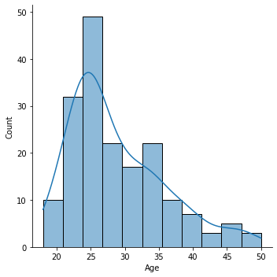

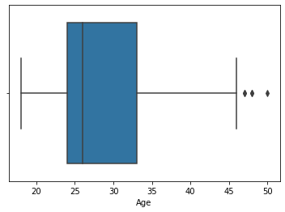

```python
sns.displot(data_new_age,kde='True')
plt.show()
sns.boxplot(data_new_age)
plt.show()
```

*The distribution is skewed towards right

*Some outliers present in this column

*Values above 46 years old represented as outliers in the boxplot

*Its positively skewed right since since whisker is shorter on the left end of the box

### 4.2Second SALARY is selected for Univariate Analysis

```python
data_new=pd.read_csv('/content/drive/MyDrive/GreatLearning/Project_CardioGoodFitness/CardioGoodFitness.csv')
```

```python
data_new_income=data_new['Income']
```

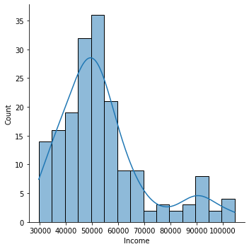

```python
sns.displot(data_new_income,kde="True")
```

The distribution is skewd towards right

[figure not shown]

```python
sns.boxplot(data_new)
```

Outliers exits clearly at boxplot

Its positively skewed right since since whisker is shorter on the left end of the box

# 5-MULTIVARIATE ANALYSIS

Multivariate analysis is performed to understand interactions between different fields in the dataset (or) finding interactions between variables more than 2

```python
data_mulvaranalys=pd.read_csv('/content/drive/MyDrive/GreatLearning/Project_CardioGoodFitness/CardioGoodFitness.csv')
```

```python
data_mulvaranalys.head()
```

|  | Product | Age | Gender | Education | MaritalStatus | Usage | Fitness | Income | Miles |
| --- | --- | --- | --- | --- | --- | --- | --- | --- | --- |
| 0 | TM195 | 18 | Male | 14 | Single | 3 | 4 | 29562 | 112 |
| 1 | TM195 | 19 | Male | 15 | Single | 2 | 3 | 31836 | 75 |
| 2 | TM195 | 19 | Female | 14 | Partnered | 4 | 3 | 30699 | 66 |
| 3 | TM195 | 19 | Male | 12 | Single | 3 | 3 | 32973 | 85 |
| 4 | TM195 | 20 | Male | 13 | Partnered | 4 | 2 | 35247 | 47 |

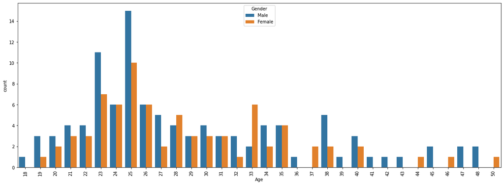

```python
plt.figure(figsize=(20,7))
sns.countplot(data=data_mulvaranalys,x='Age',hue='Gender')
plt.xticks(rotation=90)
```

*Male and Female activity is decreasing while the age is increasing

*At Age 18,36,41,42,43,45,47,48 no Female activity exits

*At Age 37,44,46,50 no male activity exits

*At age 25 there is a huge gap between Male and females

*Males are coing more ofen than females

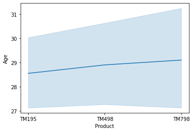

```python
sns.lineplot(data=data_mulvaranalys,x="Product",y="Age")
```

```python
data_mulvaranalys.corr()
```

|  | Age | Education | Usage | Fitness | Income | Miles |
| --- | --- | --- | --- | --- | --- | --- |
| Age | 1.000 | 0.280 | 0.015 | 0.061 | 0.513 | 0.037 |
| Education | 0.280 | 1.000 | 0.395 | 0.411 | 0.626 | 0.307 |
| Usage | 0.015 | 0.395 | 1.000 | 0.669 | 0.520 | 0.759 |
| Fitness | 0.061 | 0.411 | 0.669 | 1.000 | 0.535 | 0.786 |
| Income | 0.513 | 0.626 | 0.520 | 0.535 | 1.000 | 0.543 |
| Miles | 0.037 | 0.307 | 0.759 | 0.786 | 0.543 | 1.000 |

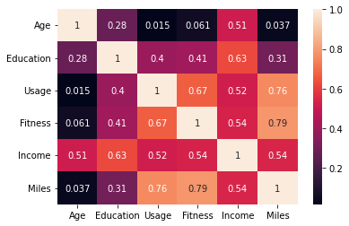

```python
sns.heatmap(data_mulvaranalys.corr(),annot=True)
```

High correlation exits between Income and Education (More educated people earns more money)

High correlation exits between Fitness and Usage (More use get more fit)

High correlation exits with Usage and Income (Money is a criteria of coming to fitness)

High correlation exits between Miles and Usage (More use get more miles)

High correlation exits between Fitness and Income (When income grows people take care of to be Fit)

High correlation exits between Age and Income (Income grows while age is increasing)

# 6-CONCLUSION AND RECOMMENDATION: